# Exploring the InsideAirbnb Data for Amsterdam, Paris & New York

## Introduction

This study provides an analysis of the fluctuations of price during select major holidays, in combination with other variables, on Airbnb listings in Amsterdam, Paris, and New York. This initial report serves as an exploration of the raw data in the datasets for each city by going through some of the key variables.

### The Interaction Between Price and Review Rating

The price and reviews of an Airbnb listing are often one of the first things potential customers check when browsing the website. As such, these scatter plots provide an overview of the interaction between both variables in each city, specifically by checking the average review rating for listings in each price category.

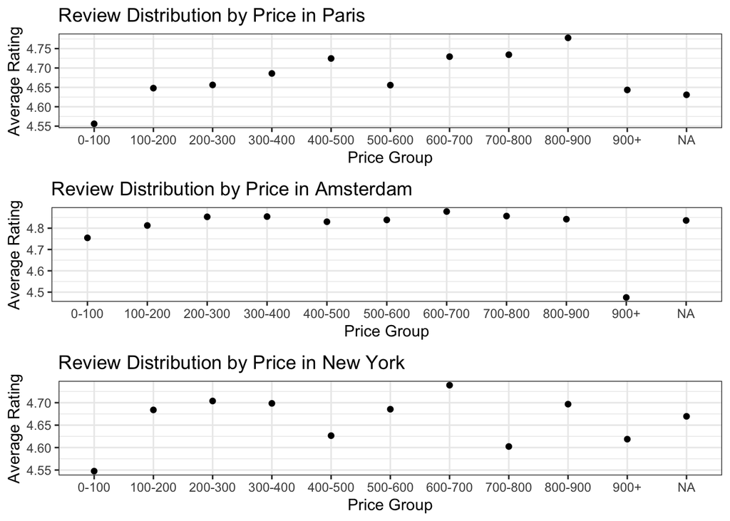

In Paris and New York, the listings in the lowest price range tend to have lower average review ratings than the higher price ranges. Moreover, a slight dip in the average review rating is observed for listings in the middle price ranges for both cities. In Amsterdam, however, the scatter plot indicates that the average rating is consistently high across all of the price ranges until $900. Interestingly, all three cities experience a dip in the average rating for listings priced above $900.

### The Number of Listings

Plotting the total number of listings in each city helps to gain a better understanding of the size of the datasets for each city.

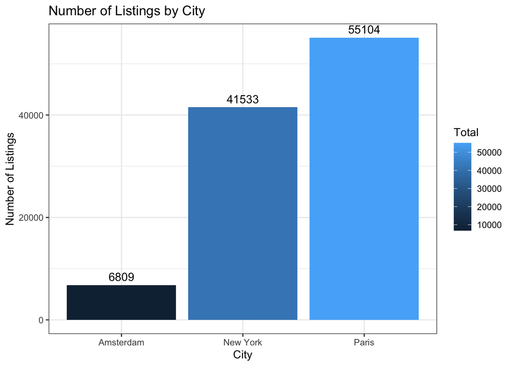

The bar chart highlights a difference in the number of listings in each city, with Amsterdam having the lowest number of listings. On the other end, Paris has the highest number of listings and New York falls in between the two in terms of the number of listings.

### The Types of Rooms Available in Each City

Following on from the number of listings in each city, it may be interesting to explore the distribution of the types of rooms available in each city.

[figure not shown]

### Listings Made by a Super Host

Being a ‘Super Host’ on Airbnb is typically a positive indicator to potential customers as the listing can be trusted due to a number of factors, including previous positive experiences by other customers, a high response rate, among others.

| Super Host Status | Paris | Amsterdam | New York |
| --- | --- | --- | --- |
| Yes | 7564 | 1318 | 8869 |
| No | 47498 | 5487 | 32635 |
| Not Indicated | 42 | 4 | 29 |

The number of listings that are made by a super host in each city evidently make up just a fraction of the total number of listings, which is as expected as the super host tag is only awarded to the most reputable hosts on the platform. Interestingly, the percentage of listings made by super hosts in Amsterdam and New York is approximately 20% of the total listings, whereas in Paris, this percentage is relatively lower.

### The Number of Guests

The number of guests that a particular Airbnb can accommodate is also relevant to potential consumers when searching on the platform.

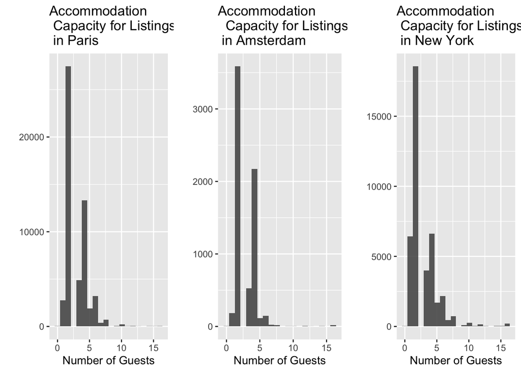

The histograms indicate that a majority of listings, across the three cities, can accommodate less than 5 guests. There are listings, however, that are able to host larger groups, especially in New York compared to Amsterdam and Paris.

### Overview

This report on the exploration of the datasets for the three cities leads to a comprehensive overview of the data and highlights possible trends in key variables. Building on these insights, this study will focus on some of the variables highlighted in this report in order to perform an analysis on the fluctuations of price during select major holidays.